# 705assign4_guide_pyth

# Libraries

```python
import pandas as pa # data manipulation
import numpy as ny # math functions
import scipy.stats as scy # stats functions
import matplotlib.pyplot as pyp # plotting
from sklearn.linear_model import LinearRegression as LM # linear model
from sklearn.linear_model import Lasso # variable selection
from sklearn.preprocessing import StandardScaler # standardization
from sklearn.pipeline import make_pipeline # necessary lasso setup
from sklearn.metrics import mean_squared_error as mse # mean squared error
from sklearn.utils import resample # bootstrap functionality
```

# Data Import

```python
url="https://raw.githubusercontent.com/jlacasa/stat705_fall2024/main/classes/data/prostate.csv"
dd=pa.read_csv(url)
```

# Data Split

```python
# training and testing split
train=dd[dd['train']==True]
test=dd[dd['train']==False]
```

# Exploratory Analysis

Exploratory analyses are my preferred first step in any statistics/data analysis project. I’m starting by printing the head of my data to get an idea of variable names and data types, (i.e., whether the data is discrete or continuous).

```python
# first 10 rows of each column
print(dd.head(10))
```

```
     lcavol   lweight  age      lbph  svi       lcp  gleason  pgg45      lpsa  \
0 -0.579818  2.769459   50 -1.386294    0 -1.386294        6      0 -0.430783
1 -0.994252  3.319626   58 -1.386294    0 -1.386294        6      0 -0.162519
2 -0.510826  2.691243   74 -1.386294    0 -1.386294        7     20 -0.162519
3 -1.203973  3.282789   58 -1.386294    0 -1.386294        6      0 -0.162519
4  0.751416  3.432373   62 -1.386294    0 -1.386294        6      0  0.371564
5 -1.049822  3.228826   50 -1.386294    0 -1.386294        6      0  0.765468
6  0.737164  3.473518   64  0.615186    0 -1.386294        6      0  0.765468
7  0.693147  3.539509   58  1.536867    0 -1.386294        6      0  0.854415
8 -0.776529  3.539509   47 -1.386294    0 -1.386294        6      0  1.047319
9  0.223144  3.244544   63 -1.386294    0 -1.386294        6      0  1.047319

   train
0   True
1   True
2   True
3   True
4   True
5   True
6  False
7   True
8  False
9  False
```

Next I plotted a histogram of my intended response variable, `lpsa`, to get a rough read on how the data is distributed.

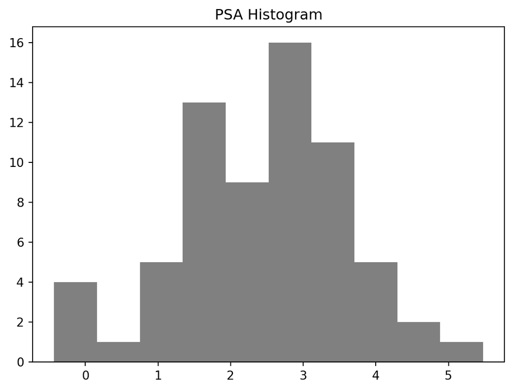

```python
# observing the response distribution
pyp.hist(train['lpsa'],color='grey')
pyp.title("PSA Histogram")
pyp.show()
pyp.close('all') # i make use of close('all') frequently
# i know there's better functions, im just a boomer
```

Then I’m just plotting my response against various possible predictor variables. `pgg45` and `svi` were avoided because of high incidence of $0$ values, and `lbph` was honestly just missed in the moment.

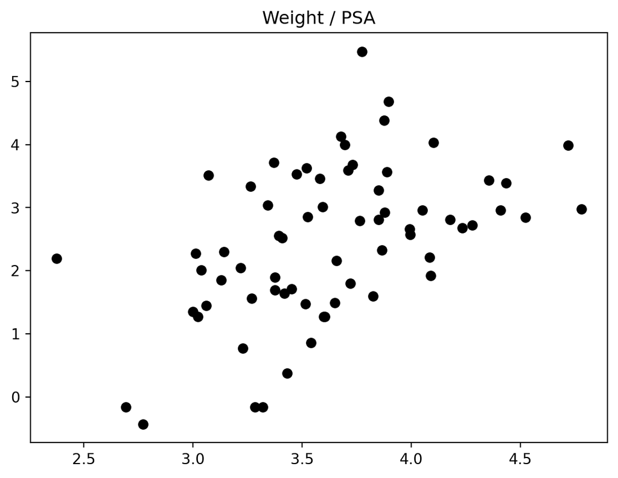

```python
# weight by response
pyp.scatter(train['lweight'],train['lpsa'],color='black')
pyp.title("Weight / PSA")
pyp.show()
pyp.close('all')
```

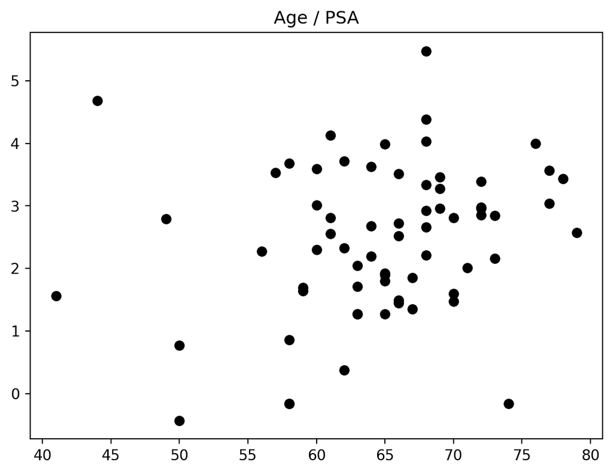

```python
# age by response
pyp.scatter(train['age'],train['lpsa'],color='black')
pyp.title("Age / PSA")
pyp.show()
pyp.close('all')
```

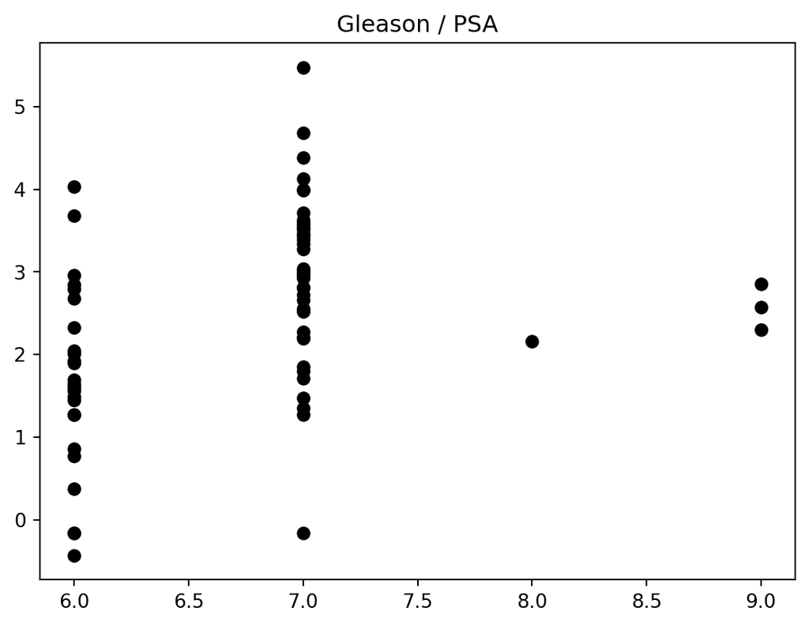

```python
# gleason by response
pyp.scatter(train['gleason'],train['lpsa'],color='black')
pyp.title("Gleason / PSA")
pyp.show()
pyp.close('all')
```

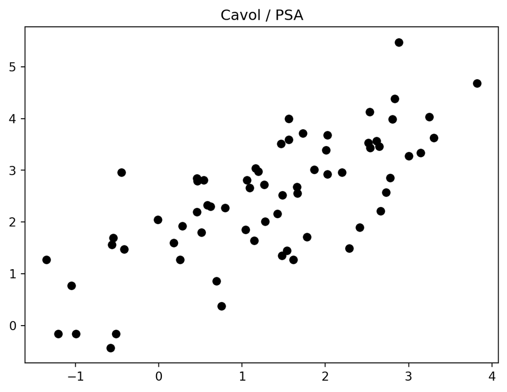

```python
# cavol by response
pyp.scatter(train['lcavol'],train['lpsa'],color='black')
pyp.title("Cavol / PSA")
pyp.show()
pyp.close('all')
```

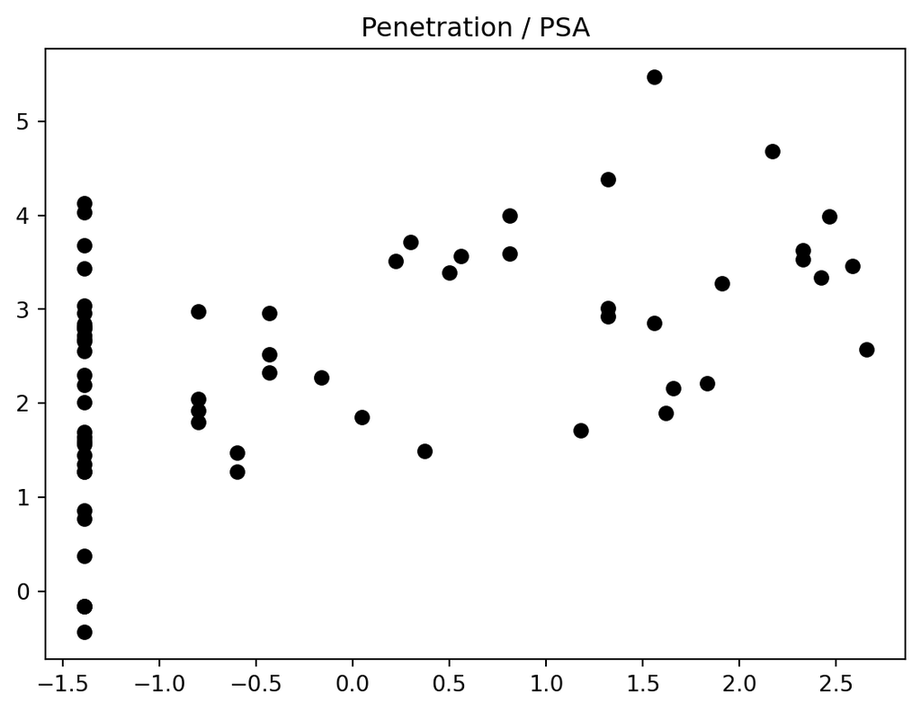

```python
# penetration by response
pyp.scatter(train['lcp'],train['lpsa'],color='black')
pyp.title("Penetration / PSA")
pyp.show()
pyp.close('all')
```

# LASSO

I chose to pair my graphical selection with LASSO as a form of “fact check” for my gut feeling.

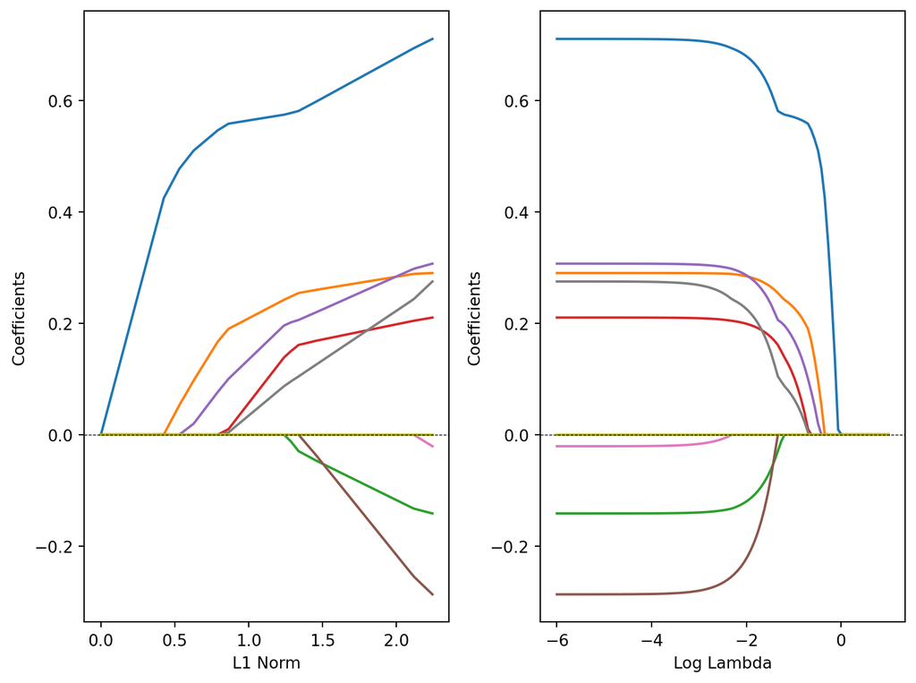

```python
# everything about this was terrible
# just learn R
LY=train['lpsa'] # separated Y
                # (unnecessary but helped with troubleshooting)
LX=train.drop(columns=['lpsa']) # full X matrix

lasso=Lasso(alpha=1.0) # regularlization strength
m=make_pipeline(StandardScaler(),lasso) # pipeline with standardization
m.fit(LX,LY) # fit full model

alphas=ny.logspace(-6,1,100) # logscale vector
coefs=[] # empty coefficient list
l1_norms=[] # empty l1 norms list

scaler=StandardScaler() # standardization (removing mean)
LX_scaled=scaler.fit_transform(LX) # fit and transform to standardized vector

# lasso loop
for alpha in alphas:
    lasso=Lasso(alpha=alpha,max_iter=10000)
    lasso.fit(LX_scaled,LY)
    coefs.append(lasso.coef_)
    l1_norms.append(ny.sum(ny.abs(lasso.coef_)))

coefs=ny.array(coefs) # fill coefs list

# final figure plotting
pyp.figure(figsize=(8,6)) # this was also terrible, just learn R
pyp.subplot(1,2,1)
for i in range(coefs.shape[1]):
    pyp.plot(l1_norms,coefs[:,i])
pyp.xlabel('L1 Norm')
pyp.ylabel('Coefficients')
pyp.axhline(0,color='black',linestyle='--',linewidth=0.5)

pyp.subplot(1,2,2)
for i in range(coefs.shape[1]):
    pyp.plot(ny.log10(alphas),coefs[:,i])
pyp.xlabel('Log Lambda')
pyp.ylabel('Coefficients')
pyp.axhline(0,color='black',linestyle='--',linewidth=0.5)

pyp.tight_layout()
pyp.show()
pyp.close('all')
```

Since I ended up fitting this essentially by hand (StackExchange did a ton of the heavy lifting), I avoided printing the same coefficient values as I did in R because it was cumbersome and far beyond my complete understanding of this process.

# Model Proposals

I investigated two possible models, for simplicity sake I *capped* my models at $3$ predictors, rather than considering it a minimum. Both models will include `lweight` and `age`, while the difference between each model will be the inclusion of `gleason` versus `lcavol`.

My goal was to make a simple comparison and get a high performing model with *good calibration* without muddying up the interpretation with too many variables.

**Model 1**

$$y_{ij}=\beta_0+\beta_1w+\beta_2a+\beta_3t_j+\epsilon_{ij}$$

$$\text{Where} : t_j=\begin{cases}
0 & \text{Season}=6\\
1 & \text{Season}=7\\
2 & \text{Season}=8\\
3 & \text{Season}=9\\
\end{cases}$$

$$\epsilon_{ij} \sim N(0,\sigma^2)$$

**Model 2**

$$y_{i}=\beta_0+\beta_1w+\beta_2a+\beta_3c+\epsilon_{i}$$

$$\epsilon_{i} \sim N(0,\sigma^2)$$

# Model Fitting

```python
X=train[['lweight','age']] # base X matrix
# dummies serve as a viable analog to factorizing a value
gl_dum=pa.get_dummies(train['gleason'],
prefix='gleason',drop_first=True)
# bind the dummies to base X matrix for model 1
m1_X=pa.concat([X,gl_dum],axis=1)
# model 2 X matrix
m2_X=train[['lweight','age','lcavol']]
Y=train[['lpsa']] # response matrix

# i don't do enough statistics in python to have
# found a preference on library for lm() functions
# i used this one because it's simple and the documentation was easy
m1=LM().fit(m1_X,Y)
m2=LM().fit(m2_X,Y)
```

# Model Evaluation

### Outputs

```python
# basic coefficient summaries
print(m1.intercept_,m1.coef_)
print(m2.intercept_,m2.coef_)
```

```
[-1.80148661] [[ 1.22428095 -0.01463659  1.24612983  0.55016093  1.05301552]]
[-0.59868012] [[ 0.77540056 -0.00927429  0.63937616]]
```

### Graphical Evaluation

These graphical evaluations are just to filter out anything egregious, nothing beyond that.

```python
# predictions to get residuals
m1_pred=m1.predict(m1_X)
m2_pred=m2.predict(m2_X)
# actual minus predicted
m1_res=Y-m1_pred
m2_res=Y-m2_pred
```

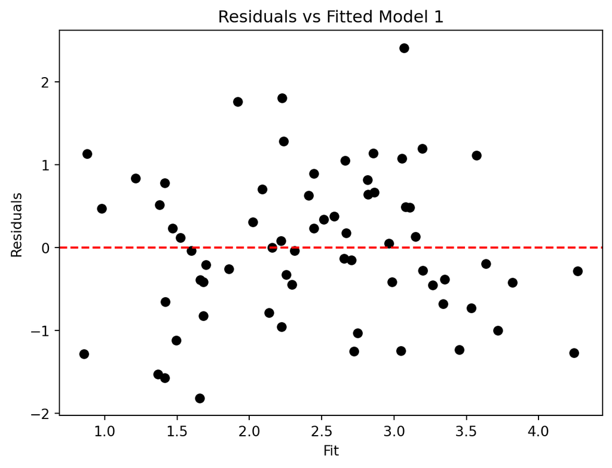

```python
# residual vs fit m1
pyp.scatter(m1_pred,m1_res,color='black')
pyp.axhline(y=0,color='r',linestyle='--')
pyp.xlabel('Fit')
pyp.ylabel('Residuals')
pyp.title('Residuals vs Fitted Model 1')
pyp.show()
pyp.close('all')
```

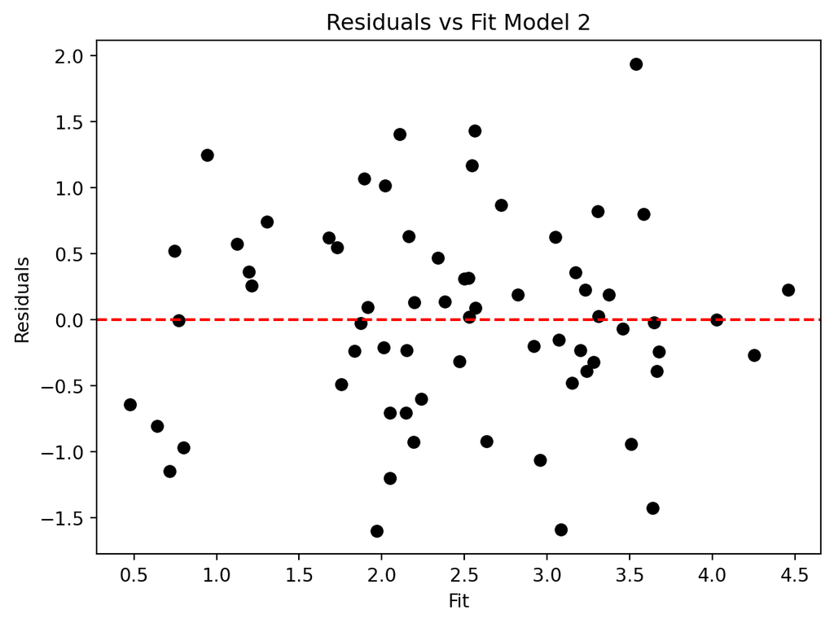

```python
# residual vs fit m2
pyp.scatter(m2_pred,m2_res,color='black')
pyp.axhline(y=0,color='r',linestyle='--')
pyp.xlabel('Fit')
pyp.ylabel('Residuals')
pyp.title('Residuals vs Fit Model 2')
pyp.show()
pyp.close('all')
```

```python
# convert to numpy object
m1_res=m1_res.values
m1_res=m1_res.flatten() # flatten to reduce later errors
m2_res=m2_res.values
m2_res=m2_res.flatten()
```

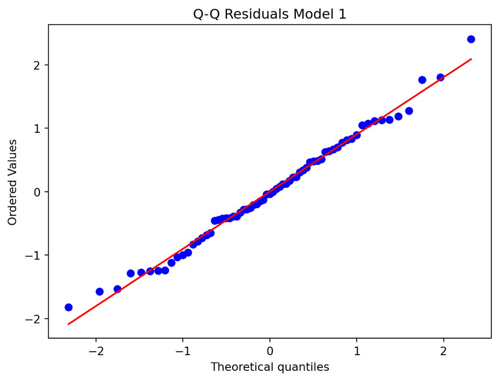

```python
# q-q residuals, a lot of my python friends have struggled with this
# i did too, this is a pretty consistent function for it
scy.probplot(m1_res,dist="norm",plot=pyp)
pyp.title("Q-Q Residuals Model 1")
pyp.show()
pyp.close('all')
```

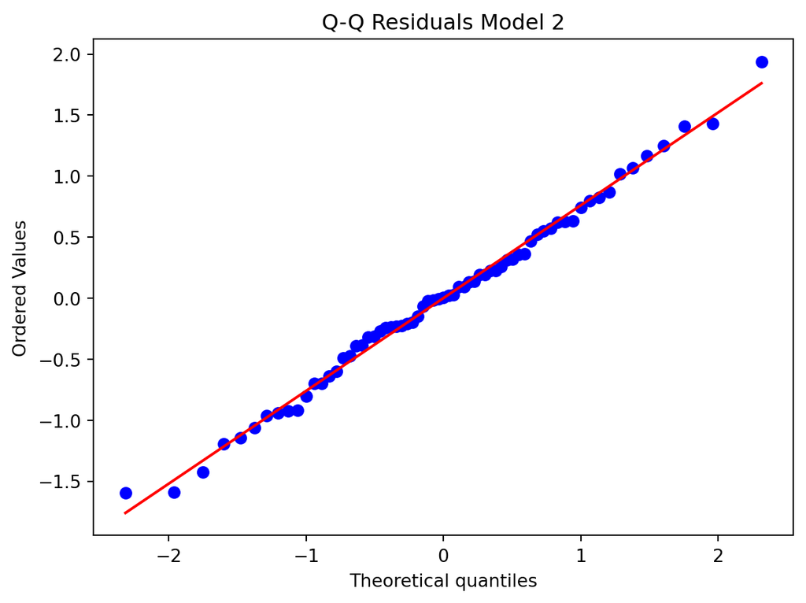

```python
scy.probplot(m2_res,dist="norm",plot=pyp)
pyp.title("Q-Q Residuals Model 2")
pyp.show()
pyp.close('all')
```

### Calibration

I checked Mean Squared Error, Root Mean Squared Error, and coverage using the testing data.

```python
# rinse/repeat the X and Y matrix prep
# but with the test set
X=test[['lweight','age']]
gl_dum_train=pa.get_dummies(train['gleason'],
prefix='gleason',drop_first=True)
gl_dum_test=pa.get_dummies(test['gleason'],
prefix='gleason',drop_first=True)
gl_dum_test=gl_dum_test.reindex(columns=gl_dum_train.columns,
fill_value=0)
m1_X_test=pa.concat([X,gl_dum_test],axis=1)
m2_X_test=test[['lweight','age','lcavol']]
Y_test=test[['lpsa']]

# predictions from the test set
m1_pred_t=m1.predict(m1_X_test)
m2_pred_t=m2.predict(m2_X_test)

MSE_m1=mse(Y_test,m1_pred_t) # mean squared error
rMSE_m1=ny.sqrt(MSE_m1) # root mean squared error
MSE_m2=mse(Y_test,m2_pred_t)
rMSE_m2=ny.sqrt(MSE_m2)
```

```python
print(MSE_m1)
```

```
0.9167180524122771
```

```python
print(rMSE_m1)
```

```
0.9574539427107066
```

```python
print(MSE_m2)
```

```
0.4800778387223387
```

```python
print(rMSE_m2)
```

```
0.6928764960094539
```

```python
# dimensions of X matrix
n=m1_X.shape[0]
p=m1_X.shape[1]

# summary statistics for prediction intervals
rss=ny.sum(m1_res**2)
s2=rss/(n-p-1)
sigma=ny.sqrt(s2)
sigma=float(sigma) # this float haunted me
                    # if it isn't here everything breaks

# prediction from the test but flattened
m1_pred=m1.predict(m1_X_test).flatten()

# i just converted everything to a numpy object
# it took so long to make this work i lost my mind
m1_X_test_b0=ny.column_stack((ny.ones(m1_X_test.shape[0]),
m1_X_test.to_numpy().astype(float)))
m1_X_b0=ny.column_stack((ny.ones(m1_X.shape[0]),
m1_X.to_numpy().astype(float)))

# compute hat matrix
X_b0_inv=ny.linalg.inv(ny.dot(m1_X_b0.T,m1_X_b0))
H=ny.dot(m1_X_test_b0,X_b0_inv).dot(m1_X_test_b0.T)
m1_lev=ny.diag(H).flatten()

# t value for prediction interval
t_value=scy.t.ppf(0.975,df=n-p-1)

# upper and lower bounds
m1_lower=m1_pred-t_value*sigma*ny.sqrt(1+m1_lev)
m1_upper=m1_pred+t_value*sigma*ny.sqrt(1+m1_lev)

Y_test=Y_test.to_numpy().flatten()

# cover over prediction intervals
m1_cover=ny.mean((Y_test>m1_lower)&(Y_test<m1_upper))
```

```python
print(m1_cover)
```

```
0.9333333333333333
```

```python
n=m2_X.shape[0]
p=m2_X.shape[1]

rss=ny.sum(m2_res**2)
s2=rss/(n-p-1)
sigma=ny.sqrt(s2)
sigma=float(sigma)

m2_pred=m2.predict(m2_X_test).flatten()

m2_X_test_b0=ny.column_stack((ny.ones(m2_X_test.shape[0]),
m2_X_test.to_numpy().astype(float)))
m2_X_b0=ny.column_stack((ny.ones(m2_X.shape[0]),
m2_X.to_numpy().astype(float)))

X_b0_inv=ny.linalg.inv(ny.dot(m2_X_b0.T,m2_X_b0))
H=ny.dot(m2_X_test_b0,X_b0_inv).dot(m2_X_test_b0.T)
m2_lev=ny.diag(H).flatten()

t_value=scy.t.ppf(0.975,df=n-p-1)

m2_lower=m2_pred-t_value*sigma*ny.sqrt(1+m2_lev)
m2_upper=m2_pred+t_value*sigma*ny.sqrt(1+m2_lev)

m2_cover=ny.mean((Y_test>m2_lower)&(Y_test<m2_upper))
```

```python
print(m2_cover)
```

```
0.9666666666666667
```

The difference between the two models is almost subjective, but **Model 2** does have the best performance overall between all variable selection, within-sample checks, and out-of-sample checks.

# Bootstrapping

I concluded with bootstrapping uncertainty estimates the parameter estimates. I chose to include both models since the difference between them is not severe enough to consider one unusable.

```python
n=1000 # number of boot iterations
save_boot=[] # empty list for saving coefficients

for i in range(n):
    # sample with replacement
    X_boot,Y_boot=resample(m1_X,Y,replace=True)
    # fit sampled data
    m_boot=LM().fit(X_boot,Y_boot)
    # pull coefficients
    boot_out=ny.concatenate((m_boot.intercept_,m_boot.coef_.flatten()))
    # save coefficients
    save_boot.append(boot_out)
# organize and name coefficients
df_boot=pa.DataFrame(save_boot,columns=['b0','b1','b2','b3','b4','b5'])
# calculate summaries
boot_coefs=df_boot.describe(percentiles=[0.025, 0.975])

print(boot_coefs)
```

```
                b0           b1           b2           b3           b4  \
count  1000.000000  1000.000000  1000.000000  1000.000000  1000.000000
mean     -1.845712     1.200705    -0.012513     1.232285     0.323455
std       1.135697     0.291694     0.018407     0.231758     0.323871
min      -5.312997     0.404303    -0.066541     0.489315    -0.340773
2.5%     -3.990084     0.666926    -0.046332     0.806086     0.000000
50%      -1.856850     1.197388    -0.013980     1.233752     0.307868
97.5%     0.311719     1.819283     0.026523     1.726560     0.990818
max       2.082668     2.265220     0.058537     1.989906     1.331466

                b5
count  1000.000000
mean      0.981349
std       0.397177
min       0.000000
2.5%      0.000000
50%       1.018819
97.5%     1.683957
max       2.079295
```

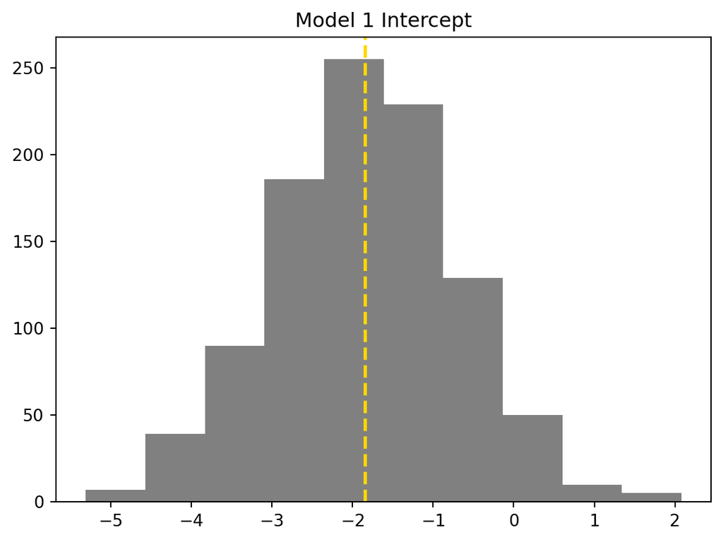

```python
# bootstrap distributions of coefficients
pyp.hist(df_boot.b0,color='grey')
pyp.title('Model 1 Intercept')
mean=ny.mean(df_boot.b0)
pyp.axvline(mean,color='gold',linestyle='dashed',linewidth=2)
pyp.show()
pyp.close('all')
```

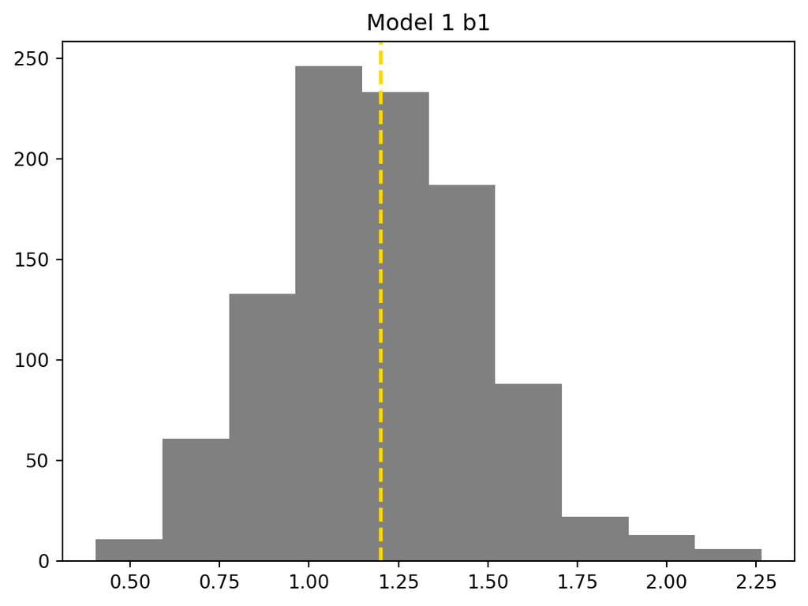

```python
pyp.hist(df_boot.b1,color='grey')
pyp.title('Model 1 b1')
mean=ny.mean(df_boot.b1)
pyp.axvline(mean,color='gold',linestyle='dashed',linewidth=2)
pyp.show()
pyp.close('all')
```

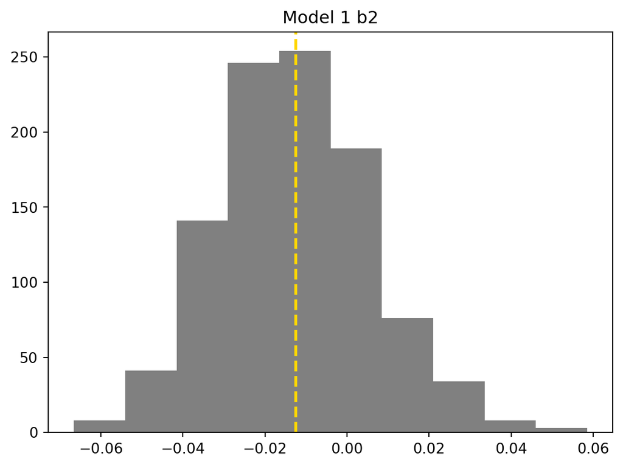

```python
pyp.hist(df_boot.b2,color='grey')
pyp.title('Model 1 b2')
mean=ny.mean(df_boot.b2)
pyp.axvline(mean,color='gold',linestyle='dashed',linewidth=2)
pyp.show()
pyp.close('all')
```

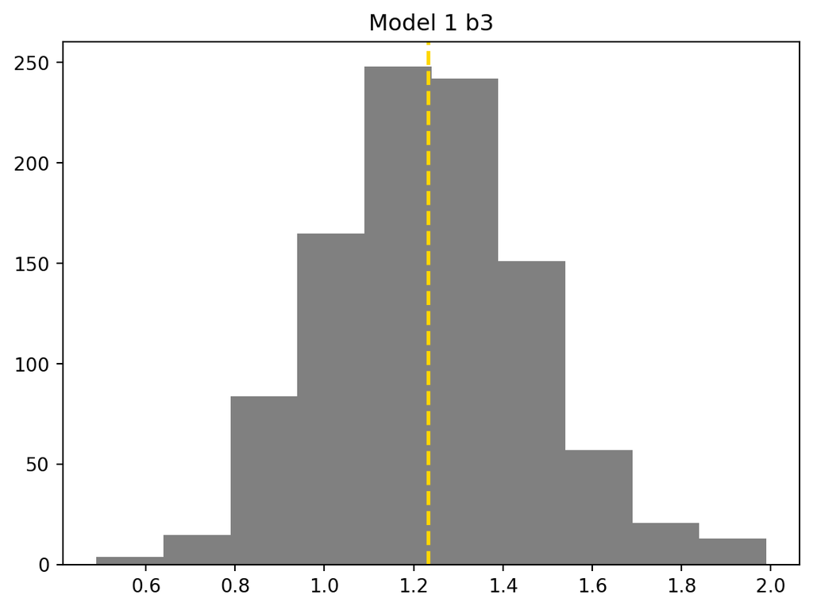

```python
pyp.hist(df_boot.b3,color='grey')
pyp.title('Model 1 b3')
mean=ny.mean(df_boot.b3)
pyp.axvline(mean,color='gold',linestyle='dashed',linewidth=2)
pyp.show()
pyp.close('all')
```

```python
n=1000
save_boot=[]

for i in range(n):

    X_boot,Y_boot=resample(m2_X,Y,replace=True)

    m_boot=LM().fit(X_boot,Y_boot)

    boot_out=ny.concatenate((m_boot.intercept_,m_boot.coef_.flatten()))

    save_boot.append(boot_out)

df_boot=pa.DataFrame(save_boot,columns=['b0','b1','b2','b3'])

boot_coefs=df_boot.describe(percentiles=[0.025,0.975])

print(boot_coefs)
```

```
                b0           b1           b2           b3
count  1000.000000  1000.000000  1000.000000  1000.000000
mean     -0.707601     0.784005    -0.008224     0.641244
std       0.926261     0.210198     0.012804     0.076553
min      -3.970061     0.109116    -0.041309     0.350498
2.5%     -2.541435     0.398566    -0.029900     0.496291
50%      -0.652980     0.779620    -0.009063     0.640420
97.5%     1.011098     1.215844     0.019604     0.784977
max       2.189422     1.410757     0.057484     0.917710
```

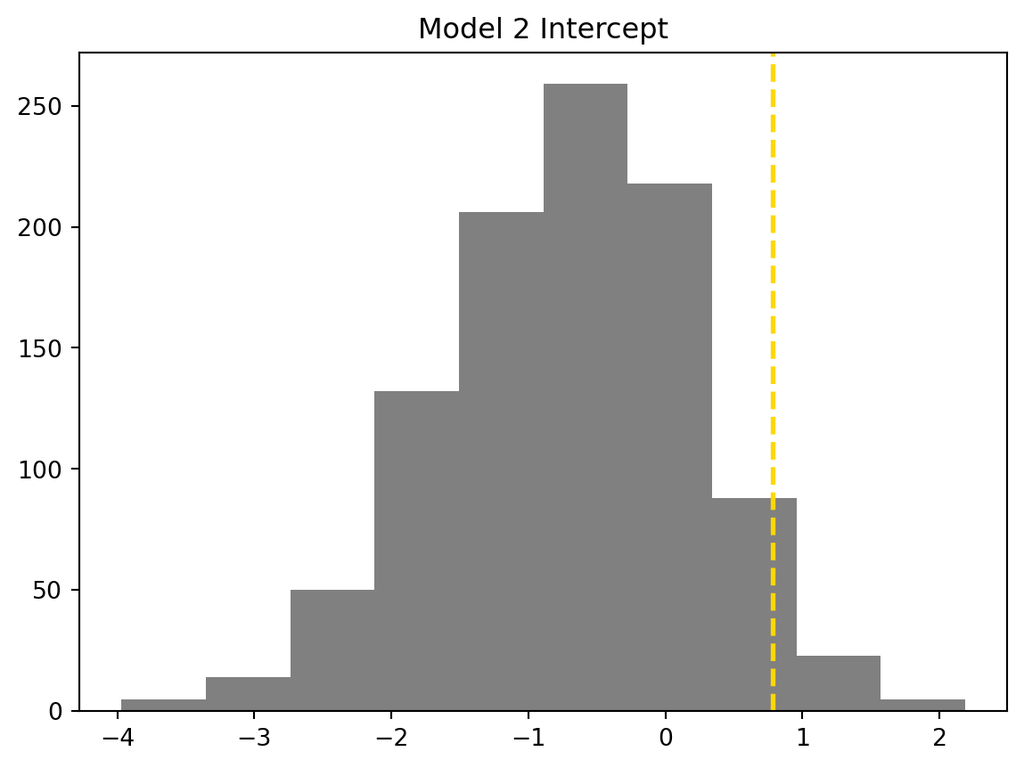

```python
pyp.hist(df_boot.b0,color='grey')
pyp.title('Model 2 Intercept')
mean=ny.mean(df_boot.b1)
pyp.axvline(mean,color='gold',linestyle='dashed',linewidth=2)
pyp.show()
pyp.close('all')
```

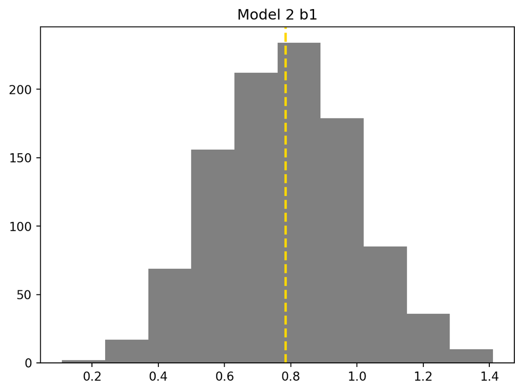

```python
pyp.hist(df_boot.b1,color='grey')
pyp.title('Model 2 b1')
mean=ny.mean(df_boot.b1)
pyp.axvline(mean,color='gold',linestyle='dashed',linewidth=2)
pyp.show()
pyp.close('all')
```

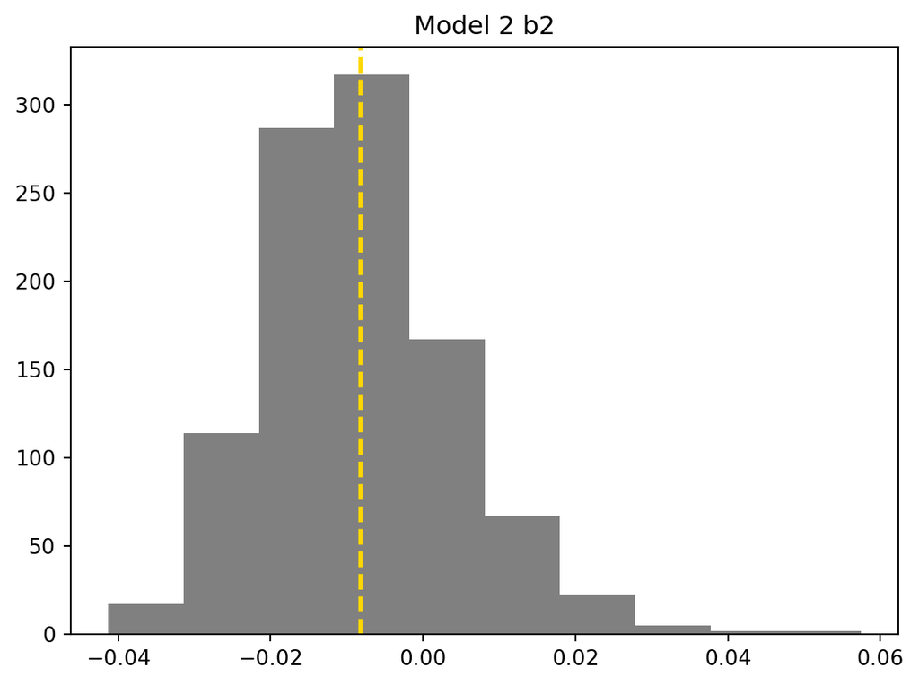

```python
pyp.hist(df_boot.b2,color='grey')
pyp.title('Model 2 b2')
mean=ny.mean(df_boot.b2)
pyp.axvline(mean,color='gold',linestyle='dashed',linewidth=2)
pyp.show()
pyp.close('all')
```

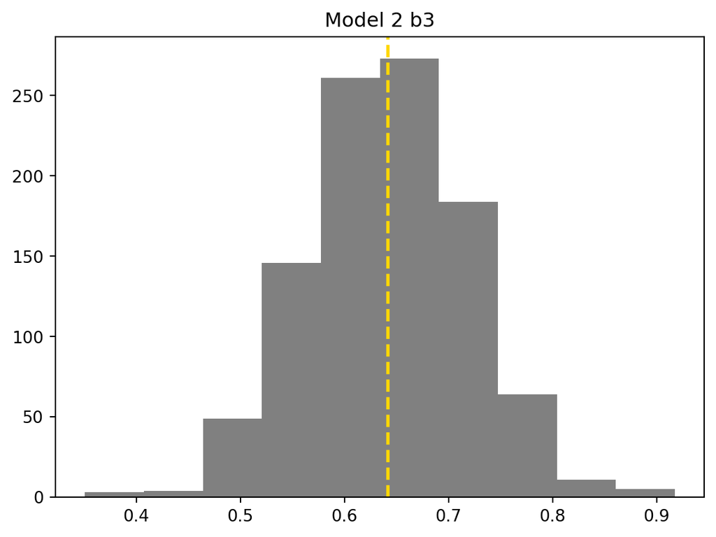

```python
pyp.hist(df_boot.b3,color='grey')
pyp.title('Model 2 b3')
mean=ny.mean(df_boot.b3)
pyp.axvline(mean,color='gold',linestyle='dashed',linewidth=2)
pyp.show()
pyp.close('all')
```